# Gait Analysis

Progetto FESI 2021/2022

A cura di Martina Brocchi con la collaborazione di Federico Fontana

## Introduzione

In questo notebook analizziamo serie temporali derivate dalla camminata di persone sane e pazienti con deficit neuromotori. In particolare analizziamo l'andamento della gamba sinistra e della gamba destra, di cui seguiamo la posizione di 4 punti anatomici (anca, ginocchio, caviglia, piede). Ad ogni punto anatomico sono associate le coordinate x e y sul piano immagine, e ad ognuna di queste corrisponde una serie temporale.

[figure not shown]

## Obiettivi

- Ricostruire il movimento della gamba tramite animazioni delle serie temporali
- Approfondire tecniche di rimozione del rumore tramite utilizzo di filtri e convoluzione (approfondimento)
- Analizzare la derivata del segnale, calcolata tramite differenze finite
- Individuare picchi e valli del segnale al fine di stabilire lunghezza e tempo dei passi
- Confrontare statistiche del passo di pazienti e persone sane

## Metodi e algoritmi

Iniziamo mettendo a confronto l'andamento della gamba destra di una persona sana e di una persona malata. Innanzitutto importiamo le librerie necessarie.

```python
import os
import pandas as pd
import numpy as np

import matplotlib.animation as animation
import matplotlib.pyplot as plt

from scipy.io import loadmat
from scipy import signal
from scipy.signal import butter,filtfilt, lfilter, find_peaks
from scipy.ndimage import convolve1d

from IPython.display import display, Markdown

from sympy import *
```

Importiamo i dati della gamba destra dei pazienti e delle persone sane

```python
def loadData(data_, dirName):
    data = []

    for file in os.listdir(dirName):
        data.append(loadmat(dirName+file))

    print("\nLista",dirName)
    for i,person in enumerate(data):
        print(i,'- ',list(person.keys())[3])
        data_.append(person[list(person.keys())[3]])

    return data_
```

```python
data_people = loadData([],'Sani/dx/')
data_patients = loadData([], 'Pazienti/dx/')
```

```
Lista Sani/dx/
0 -  S002_dx
1 -  S004_dx
2 -  S009_dx
3 -  S001_dx
4 -  S005_dx

Lista Pazienti/dx/
0 -  S_241_01_R
1 -  S_753_01_R
2 -  S_522_01_R
3 -  S_211_01_R
4 -  S_241_02_R
5 -  S_468_03_R
```

Selezioniamo ora un individuo per tipologia, di cui andremo ad analizzare i dati più nel dettaglio

```python
data_person = data_people[0]
data_patient = data_patients[0]
```

```python
print('Struttura dati persona sana: ',data_person.shape)
print('Struttura dati paziente: ',data_patient.shape)
```

```
Struttura dati persona sana:  (95, 8)
Struttura dati paziente:  (287, 8)
```

Come accennato in precedenza ogni persona possiede 8 serie temporali, ognuna delle quali è associata alle coordinate x o y dei 4 punti anatomici.

### Andamento delle serie temporali

Attraverso la funzione FuncAnimation della libreria matplotlib.animation andiamo a visualizzare un'animazione della camminata dei due individui, grazie alle coordinate x e y dei punti anatomici della gamba.

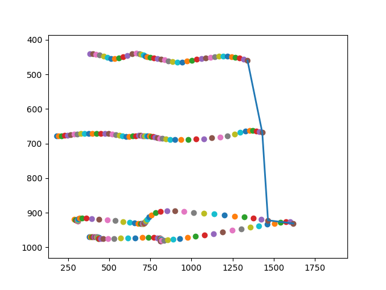

```python
%matplotlib notebook

fig = plt.figure()
ax = plt.axes(xlim =(np.nanmin(data_person[:,::2])-50, np.nanmax(data_person[:,::2])+50),ylim =(np.nanmin(data_person[:,1::2])-50,np.nanmax(data_person[:,1::2])+50))
line, = ax.plot([],[], lw=2)
plt.gca().invert_yaxis()

def init():
    line.set_data([],[])
    return line

def animate_person(i):
    x = data_person[i, ::2]
    y = data_person[i, 1::2]
    plt.scatter(x,y)
    line.set_data(x,y)
    return line

a = animation.FuncAnimation(fig, animate_person, init_func=init, frames=data_person.shape[0], interval=100)
plt.show()
```

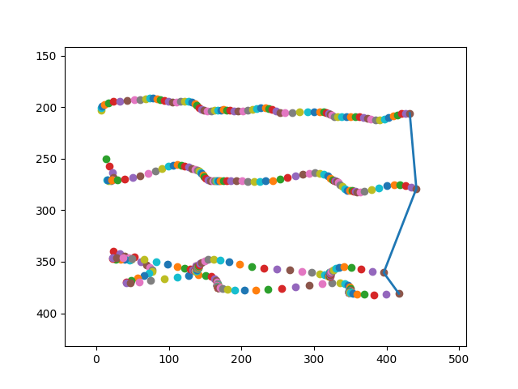

```python
fig = plt.figure()
ax = plt.axes(xlim =(np.nanmin(data_patient[:,::2])-50, np.nanmax(data_patient[:,::2])+50),ylim =(np.nanmin(data_patient[:,1::2])-50,np.nanmax(data_patient[:,1::2])+50))
line, = ax.plot([],[], lw=2)
plt.gca().invert_yaxis()

def animate_patient(i):
    x = data_patient[i, ::2]
    y = data_patient[i, 1::2]
    plt.scatter(x,y)
    line.set_data(x,y)
    return line

a = animation.FuncAnimation(fig, animate_patient, init_func=init, frames=data_patient.shape[0], interval=100)
plt.show()
```

Come possiamo notare già dalle animazioni la camminata della persona sana appare più veloce e regolare di quella del paziente. L'animazione del paziente inizialmente mette in evidenza un po' di confusione nei punti di caviglia e piede.

Analizziamo in particolare il piede dei due individui, tracciando il grafico del suo movimento nello spazio.

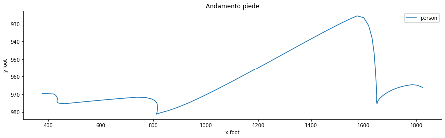

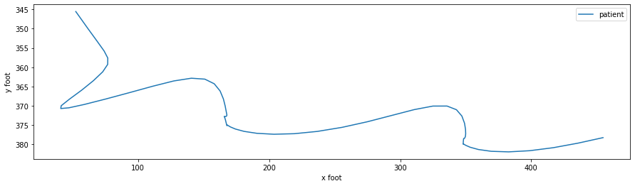

```python
%matplotlib inline

plt.figure(figsize=(15,4))
plt.plot(data_person[:,6], data_person[:,7])
plt.title("Andamento piede")
plt.legend(["person"])
plt.xlabel("x foot")
plt.ylabel("y foot")
plt.gca().invert_yaxis()
plt.show()

plt.figure(figsize=(15,4))
plt.plot(data_patient[:,6], data_patient[:,7])
plt.legend(["patient"])
plt.xlabel("x foot")
plt.ylabel("y foot")
plt.gca().invert_yaxis()
plt.show()
```

Il grafico del paziente ha un andamento particolare, probabilmente dovuto al fatto che il movimento della gamba non fosse parallelo alla telecamera bensì obliquo. Andiamo ora ad analizzare il grafico in funzione del tempo (frame) delle serie temporali riguardanti il movimento lungo l'asse x del piede.

```python
def plot_series(data, serie, legend, ylabel):
    plt.figure(figsize=(15,4))
    plt.plot(data[:,serie])
    plt.title("Serie temporale ascisse piede")
    plt.legend([legend])
    plt.xlabel('frame')
    plt.ylabel(ylabel)
    plt.show()
```

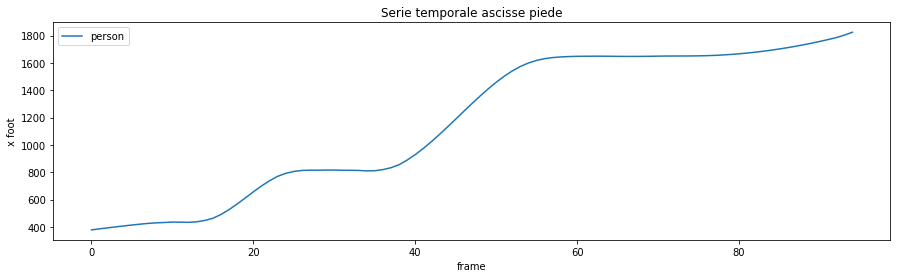

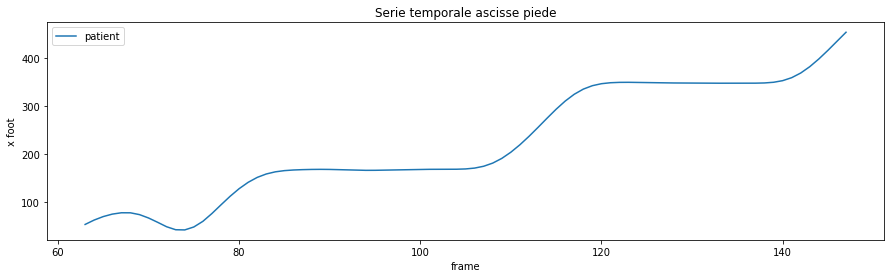

```python
serie = 6
plot_series(data_person, serie, 'person', 'x foot')
plot_series(data_patient, serie, 'patient', 'x foot')
```

Come possiamo osservare dal grafico la serie temporale delle ascisse del paziente contiene dei valori nulli (nan) all'inizio e alla fine, ma non in posizioni centrali. Al fine dell'analisi del segnale tali valori possono essere scartati.

```python
print (np.where(np.isnan(data_patient[:,serie])))
```

```
(array([  0,   1,   2,   3,   4,   5,   6,   7,   8,   9,  10,  11,  12,
        13,  14,  15,  16,  17,  18,  19,  20,  21,  22,  23,  24,  25,
        26,  27,  28,  29,  30,  31,  32,  33,  34,  35,  36,  37,  38,
        39,  40,  41,  42,  43,  44,  45,  46,  47,  48,  49,  50,  51,
        52,  53,  54,  55,  56,  57,  58,  59,  60,  61,  62, 148, 149,
       150, 151, 152, 153, 154, 155, 156, 157, 158, 159, 160, 161, 162,
       163, 164, 165, 166, 167, 168, 169, 170, 171, 172, 173, 174, 175,
       176, 177, 178, 179, 180, 181, 182, 183, 184, 185, 186, 187, 188,
       189, 190, 191, 192, 193, 194, 195, 196, 197, 198, 199, 200, 201,
       202, 203, 204, 205, 206, 207, 208, 209, 210, 211, 212, 213, 214,
       215, 216, 217, 218, 219, 220, 221, 222, 223, 224, 225, 226, 227,
       228, 229, 230, 231, 232, 233, 234, 235, 236, 237, 238, 239, 240,
       241, 242, 243, 244, 245, 246, 247, 248, 249, 250, 251, 252, 253,
       254, 255, 256, 257, 258, 259, 260, 261, 262, 263, 264, 265, 266,
       267, 268, 269, 270, 271, 272, 273, 274, 275, 276, 277, 278, 279,
       280, 281, 282, 283, 284, 285, 286]),)
```

```python
min = 63
max = 147
```

### Rumore e filtri

Andiamo a rappresentare il segnale di paziente e soggetto sano nelle frequenze tramite la trasformata di Fourier.

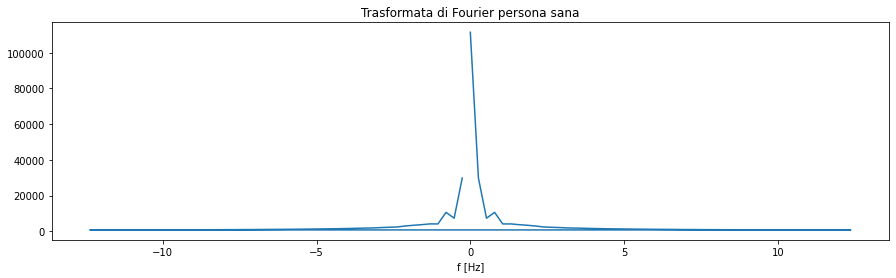

```python
fs = 25 #frequenza campionamento video - frame al secondo (fps)
fft_person = np.fft.fft(data_person[:,serie])
n1 = len(fft_person) #numero di frame
freq = np.fft.fftfreq(n1, 1/fs) #frequenze campionate da trasformata fourier

plt.figure(figsize=(15,4))
plt.plot(freq,np.abs(fft_person))
plt.title('Trasformata di Fourier persona sana')
plt.xlabel('f [Hz]')
plt.show()
```

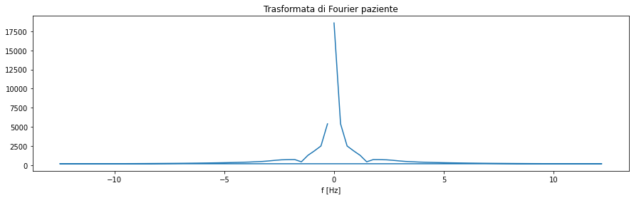

```python
fft_patient = np.fft.fft(data_patient[min:max, serie])
n2 = len(fft_patient) #numero di frame
freq = np.fft.fftfreq(n2, 1/fs)

plt.figure(figsize=(15,4))
plt.plot(freq,np.abs(fft_patient))
plt.title('Trasformata di Fourier paziente')
plt.xlabel('f [Hz]')
plt.show()
```

Come possiamo osservare in entrambi i casi il segnale è pulito: non è possibile rilevare la camminata umana con una frequenza maggiore di 12Hz, ma tutte le frequenze dei segnali sono ampiamente sotto tale soglia. Possiamo quindi concludere che non sia presente del rumore e che quindi non sia necessario applicare un filtro passa basso.

Per approfondire l'uso dei filtri simuliamo la presenza di rumore: andiamo ad aggiungere manualmente del rumore al segnale del paziente, che cercheremo successivamente di eliminare.

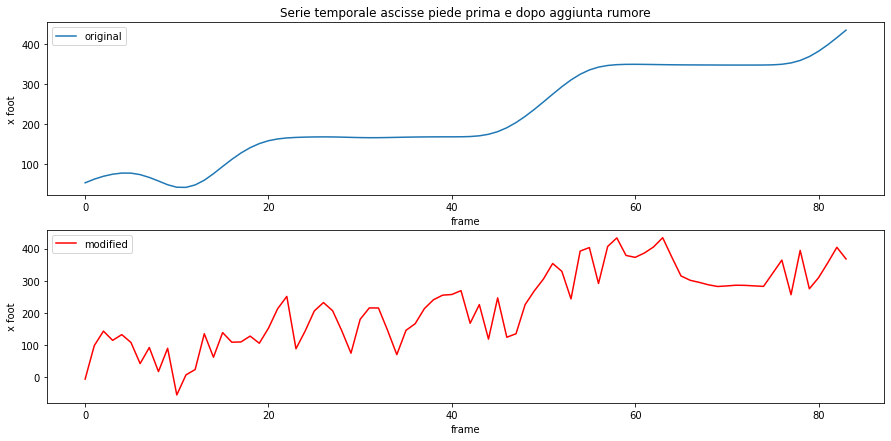

```python
f_patient = np.copy(data_patient[min:max,serie])
f_patient +=  np.random.uniform(10,30)*np.cos(2 * np.pi * f_patient) + np.random.uniform(0,100)* np.cos(0.75 * np.pi * f_patient) + np.random.uniform(0, 20)* np.cos(3.45 * np.pi * f_patient)

plt.figure(figsize=(15,7))
plt.subplot(2,1,1)
plt.plot(data_patient[min:max, serie])
plt.legend(['original'])
plt.title('Serie temporale ascisse piede prima e dopo aggiunta rumore')
plt.xlabel("frame")
plt.ylabel("x foot")

plt.subplot(2,1,2)
plt.plot(np.real(f_patient),'r')
plt.legend(['modified'])
plt.xlabel("frame")
plt.ylabel("x foot")
plt.show()
```

Applichiamo ora un'operazione di convoluzione con una gaussiana per cercare di eliminare il rumore presente nel segnale.

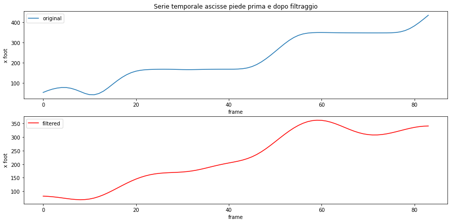

```python
windowg = signal.windows.gaussian(f_patient.shape[0], std=5) #std = deviazione standard (più alta più filtri)
windowg /= sum(windowg)
filt=convolve1d(f_patient,windowg)

plt.figure(figsize=(15,7))
plt.subplot(211)
plt.plot(data_patient[min:max, serie])
plt.title('Serie temporale ascisse piede prima e dopo filtraggio')
plt.legend(['original'])
plt.xlabel("frame")
plt.ylabel("x foot")

plt.subplot(212)
plt.plot(np.real(filt),'r')
plt.legend(['filtered'])
plt.xlabel("frame")
plt.ylabel("x foot")
plt.show()
```

Possiamo osservare come andando a convolvere nel tempo riusciamo ad eliminare il rumore inserito in precedenza, ottenendo un segnale simile a quello originario.

Possiamo confrontare il segnale ottenuto convolvendo con il segnale derivato dall'applicazione di un filtro ideale nelle frequenze.

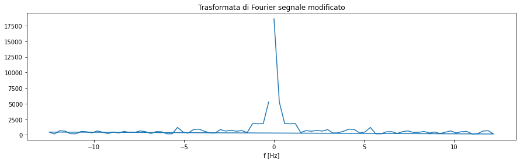

```python
fft_patient = np.fft.fft(f_patient)
n2 = len(fft_patient) #numero di frame
freq = np.fft.fftfreq(n2, 1/fs)

plt.figure(figsize=(15,4))
plt.plot(freq,np.abs(fft_patient))
plt.title('Trasformata di Fourier segnale modificato')
plt.xlabel('f [Hz]')
plt.show()
```

Andiamo ad applicare una sogliatura, ponendo a zero tutte le frequenze maggiori di 1.5 Hz.

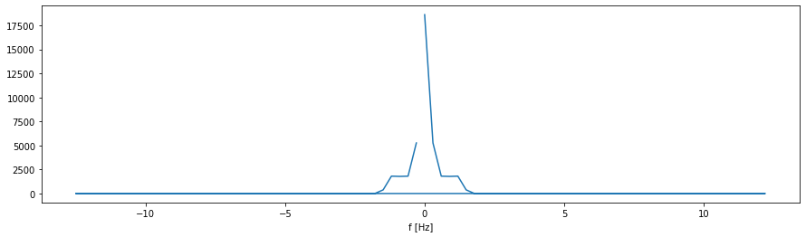

```python
idx = np.argwhere(np.abs(freq)>1.5)
fft_cut = np.copy(fft_patient)
fft_cut[idx] = 0

plt.figure(figsize=(15,4))
plt.plot(freq,np.abs(fft_cut))
plt.xlabel('f [Hz]')
```

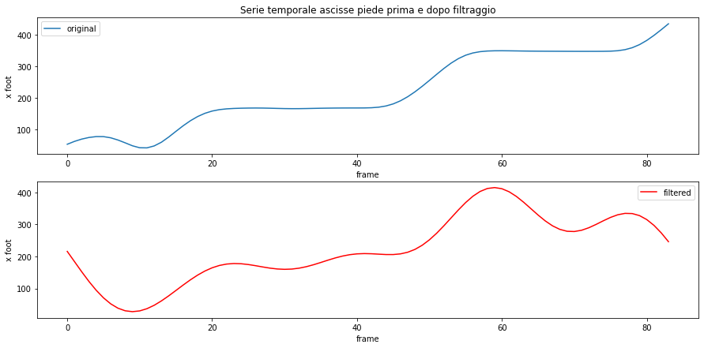

```python
f_patient = np.fft.ifft(fft_cut)

plt.figure(figsize=(15,7))
plt.subplot(211)
plt.plot(data_patient[min:max, serie])
plt.title('Serie temporale ascisse piede prima e dopo filtraggio')
plt.legend(['original'])
plt.xlabel("frame")
plt.ylabel("x foot")

plt.subplot(212)
plt.plot(np.real(f_patient),'r')
plt.legend(['filtered'])
plt.xlabel("frame")
plt.ylabel("x foot")
plt.show()
```

Il segnale ottenuto dall'applicazione del filtro ideale nelle frequenze assomiglia meno al segnale originale. Questo è dovuto al fatto che i filtri ideali creano delle discontinuità che vanno a manifestarsi nel momento in cui il segnale a cui è stato applicato il filtro viene rappresentato nel tempo tramite la trasformata inversa di Fourier.

## Analisi sperimentale

Consideriamo ora la gamba sinistra degli individui

```python
data_people = loadData([],'Sani/sx/')
data_patients = loadData([], 'Pazienti/sx/')

data_person = data_people[1]
data_patient = data_patients[2]
```

```
Lista Sani/sx/
0 -  S001_sx
1 -  S005_sx
2 -  S002_sx
3 -  S004_sx
4 -  S009_sx

Lista Pazienti/sx/
0 -  S_522_01_L
1 -  S_468_02_L
2 -  S_802_01_L
3 -  S_468_01_L
4 -  S_241_02_L
5 -  S_211_01_L
6 -  S_241_01_L
```

```python
print('Struttura dati persona sana: ',data_person.shape)
print('Struttura dati paziente: ',data_patient.shape)
```

```
Struttura dati persona sana:  (101, 8)
Struttura dati paziente:  (488, 8)
```

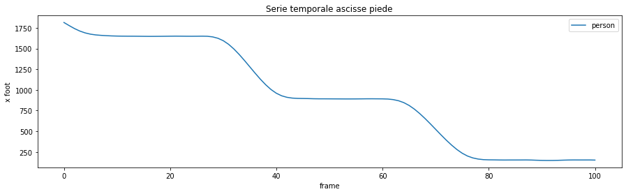

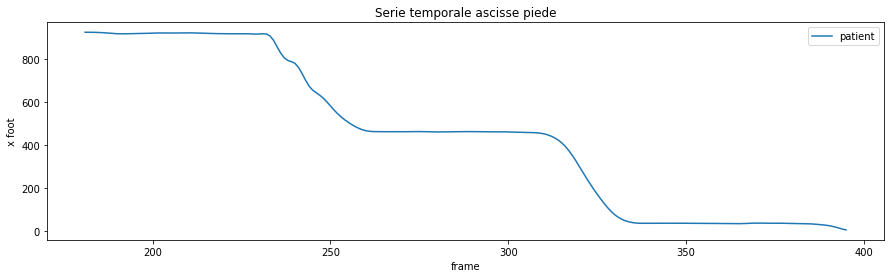

```python
plot_series(data_person, serie, 'person', 'x foot')
plot_series(data_patient, serie, 'patient', 'x foot')
```

Anche in questo caso il segnale del paziente presenta dei valori nulli, che andiamo a rimuovere con il seguente criterio:

- Se i valori nulli sono all'interno della serie, utilizziamo la funzione interpolate della libreria pandas
- Se i valori nulli sono al limite della serie andiamo a scartarli

```python
def removeNan(data):
    f_patient = np.array(pd.Series(data).interpolate(method='polynomial', order=5, limit_area='inside'))
    return f_patient[~np.isnan(f_patient)]
```

```python
f_patient = removeNan(data_patient[:,serie])
```

Siccome sappiamo che le derivate sono molto sensibili al rumore, prima di proseguire con l'analisi dei segnali andiamo ad applicare un filtro mediano. Il principio di funzionamento di questo filtro è di lavorare su un singolo campione per volta, andandolo a sostituire con il valore mediano dei suoi vicini (valori a destra e alla sinistra del campione, racchiusi in una certa finestra).

In particolare andiamo ad applicare al segnale prima un filtro mediano, e sul risultato di questo filtraggio andiamo ad applicare un filtro passa basso (convoluzione con gaussiana).

```python
def median_filter(f, std):
    filt_med=signal.medfilt(f, kernel_size=None)
    windowg = signal.windows.gaussian(f.shape[0], std= std)
    windowg /= sum(windowg)
    filt=convolve1d(filt_med,windowg)

    plt.figure(figsize=(15,4))
    plt.plot(f)
    plt.plot(filt_med)
    plt.plot(filt)
    plt.legend(['original','median','lowpass'])
    plt.title("Filtraggio")
    plt.xlabel("frame")
    plt.ylabel("x foot")
    plt.show()
    return filt
```

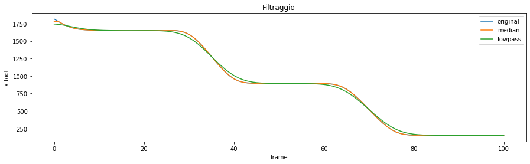

```python
filt_person = median_filter(data_person[:,serie], 3)
```

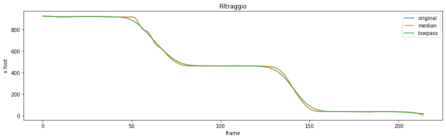

```python
filt_patient = median_filter(f_patient, 5)
```

Una volta applicati i filtri per eliminare il rumore possiamo procedere con il calcolo delle derivate.

### Differenze finite

Calcoliamo la derivata prima dei segnali tramite il calcolo delle differenze finite. In matematica discreta le differenze finite sono definite come:

$f'(x) = \frac{f(x+h)-f(x)}{h}$

```python
def derivative(f):
    h = 25
    f_prime = np.zeros(f.shape[0])
    for i in range(f.shape[0]-1):
        f_prime[i] = (-f[i+1] + f[i])/h

    return f_prime
```

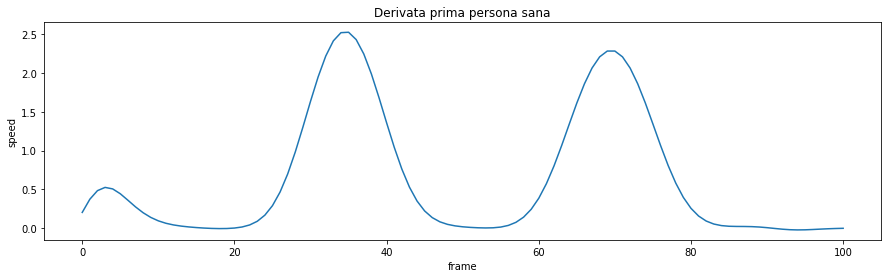

```python
f_person_prime = derivative(filt_person)
plt.figure(figsize=(15,4))
plt.plot(f_person_prime)
plt.title("Derivata prima persona sana")
plt.xlabel("frame")
plt.ylabel("speed")
plt.show()
```

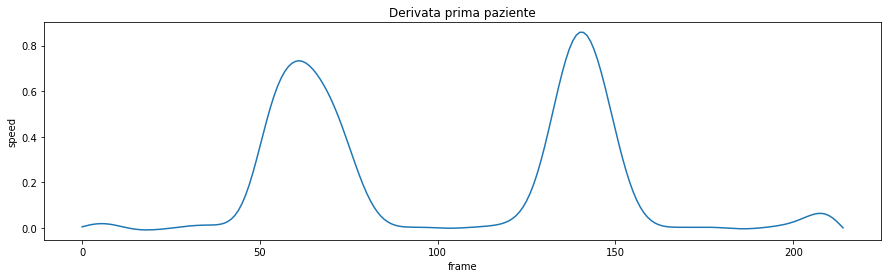

```python
f_patient_prime = derivative(filt_patient)
plt.figure(figsize=(15,4))
plt.plot(f_patient_prime)
plt.title("Derivata prima paziente")
plt.xlabel("frame")
plt.ylabel("speed")
plt.show()
```

Una volta calcolate le derivate possiamo procedere con l'identificazione di porzioni di incremento, decremento e cambi di direzione (massimi e minimi)

### Rilevamento picchi e valli

Tramite l'uso della funzione di libreria find_peaks andiamo ad individuare i massimi della derivata dei segnali. Una volta trovati i picchi procediamo, tramite la funzione valleys, ad individuare i minimi della derivata.

```python
def peaks(f):
    peaks, _ = find_peaks(f, height=0.3*np.nanmax(f), distance = 0.05*len(f))
    plt.figure(figsize=(15,4))
    plt.plot(f)
    plt.plot(peaks, f[peaks], "o")
    plt.title("Picchi derivata prima")
    plt.xlabel("frame")
    plt.ylabel("speed")
    plt.show()
    return peaks
```

```python
def valleys(f, peaks):
    max_height = 0.1*np.nanmax(f)
    tol = 0.01
    valleys = []

    for p in peaks:
        set = False
        for i in range(p,1,-1):
            if (f[i]-f[i-1]<= tol and f[i]<max_height):
                valleys.append(i)
                set = True
                break

        if (not(set)):
            valleys.append(i-1)

        set = False
        for i in range(p,len(f)-1):
            if (f[i]-f[i+1]<= tol and f[i]<max_height):
                valleys.append(i)
                set = True
                break

        if (not(set)):
            valleys.append(i+1)

    plt.figure(figsize=(15,4))
    plt.plot(f)
    plt.plot(valleys, f[valleys], "o")
    plt.title("Valli derivata prima")
    plt.xlabel("frame")
    plt.ylabel("speed")
    plt.show()
    return valleys
```

#### Persona sana

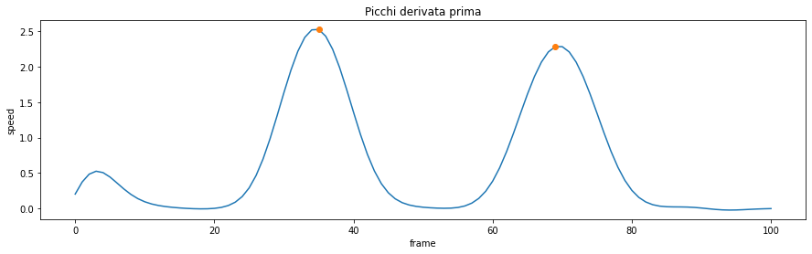

```python
person_peaks= peaks(f_person_prime)
```

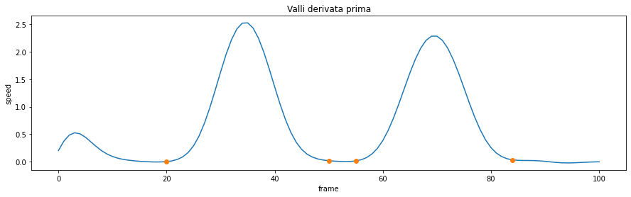

```python
person_valleys= valleys(f_person_prime, person_peaks)
```

#### Paziente

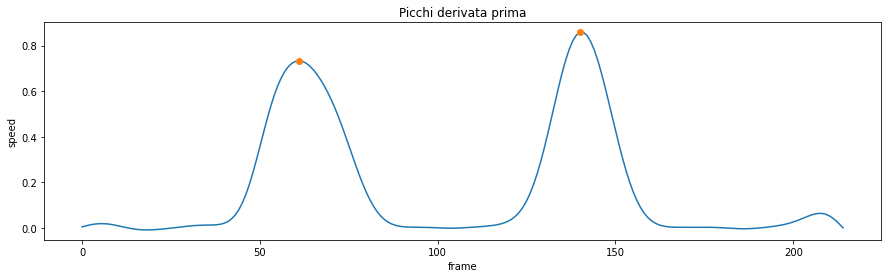

```python
patient_peaks= peaks(f_patient_prime)
```

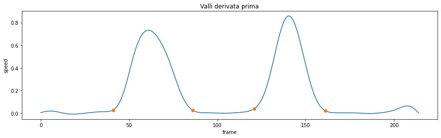

```python
patient_valleys= valleys(f_patient_prime, patient_peaks)
```